# NYPD Shooting Incident Data (Historic)

Austin Marinez

2022-06-20

# Libraries Required

```r
library(tidyverse)
library(lubridate)
```

# Source

We used https://catalog.data.gov/dataset and found the data set titled “NYPD Shooting Incident Data (Historic)”.

We downloaded the csv file, which can be downloaded through the following link: https://data.cityofnewyork.us/api/views/833y-fsy8/rows.csv?accessType=DOWNLOAD.

More information about the data collected can be found at https://data.cityofnewyork.us/Public-Safety/NYPD-Shooting-Incident-Data-Historic-/833y-fsy8.

Now that we found our data, we first read it in.

# Read In and Clean Up

```r
  nypd_data <- read_csv('https://data.cityofnewyork.us/api/views/833y-fsy8/rows.csv?accessType=DOWNLOAD')
#summary before cleaning
summary(nypd_data)
```

```
##   INCIDENT_KEY        OCCUR_DATE         OCCUR_TIME           BORO
##  Min.   :  9953245   Length:25596       Length:25596      Length:25596
##  1st Qu.: 61593633   Class :character   Class1:hms        Class :character
##  Median : 86437258   Mode  :character   Class2:difftime   Mode  :character
##  Mean   :112382648                      Mode  :numeric
##  3rd Qu.:166660833
##  Max.   :238490103
##
##     PRECINCT      JURISDICTION_CODE LOCATION_DESC      STATISTICAL_MURDER_FLAG
##  Min.   :  1.00   Min.   :0.0000    Length:25596       Mode :logical
##  1st Qu.: 44.00   1st Qu.:0.0000    Class :character   FALSE:20668
##  Median : 69.00   Median :0.0000    Mode  :character   TRUE :4928
##  Mean   : 65.87   Mean   :0.3316
##  3rd Qu.: 81.00   3rd Qu.:0.0000
##  Max.   :123.00   Max.   :2.0000
##                   NA's   :2
##  PERP_AGE_GROUP       PERP_SEX          PERP_RACE         VIC_AGE_GROUP
##  Length:25596       Length:25596       Length:25596       Length:25596
##  Class :character   Class :character   Class :character   Class :character
##  Mode  :character   Mode  :character   Mode  :character   Mode  :character
##
##
##
##
##    VIC_SEX            VIC_RACE           X_COORD_CD        Y_COORD_CD
##  Length:25596       Length:25596       Min.   : 914928   Min.   :125757
##  Class :character   Class :character   1st Qu.:1000011   1st Qu.:182782
##  Mode  :character   Mode  :character   Median :1007715   Median :194038
##                                        Mean   :1009455   Mean   :207894
##                                        3rd Qu.:1016838   3rd Qu.:239429
##                                        Max.   :1066815   Max.   :271128
##
##     Latitude       Longitude        Lon_Lat
##  Min.   :40.51   Min.   :-74.25   Length:25596
##  1st Qu.:40.67   1st Qu.:-73.94   Class :character
##  Median :40.70   Median :-73.92   Mode  :character
##  Mean   :40.74   Mean   :-73.91
##  3rd Qu.:40.82   3rd Qu.:-73.88
##  Max.   :40.91   Max.   :-73.70
##
```

Next, we make the following changes to clean up the data.

1. From looking at the summary there are many overlapping categories. UNKNOWN, U, and NA all overlap. There also seem to be some errors entered in the PERP_AGE_GROUP column. We first change these all to NA.
2. We remove columns that are not pertinent to our analysis.
3. We rename some columns for usability.
4. We change the data type of the PRECINCT column to ensure it uses factors rather than integers.
5. We change the data type of the DATE column to ensure it is considered a column of dates.
6. We change the data type of the character columns to factor as we are interested in categories.

```r
#1a entry check
cat_PAG <- unique(nypd_data$PERP_AGE_GROUP)
cat_PAG
```

```
##  [1] NA        "25-44"   "18-24"   "<18"     "45-64"   "65+"     "UNKNOWN"
##  [8] "1020"    "940"     "224"
```

```r
#1b NA change
nypd_data[nypd_data == "UNKNOWN" | nypd_data == "1020" | nypd_data == "940"  | nypd_data == "224" | nypd_data == "U"] <- NA

#2 column removal
  nypd_data_rem <- select(nypd_data, -c(INCIDENT_KEY,JURISDICTION_CODE,LOCATION_DESC,X_COORD_CD,Y_COORD_CD,Latitude,Longitude,Lon_Lat))


#3 column renaming
nypd_data_rename <- rename(nypd_data_rem, DATE=OCCUR_DATE,TIME=OCCUR_TIME,BOROUGH=BORO,MURDER=STATISTICAL_MURDER_FLAG)


#4 precinct as factor change
nypd_data_rename$PRECINCT <- as.factor(nypd_data_rename$PRECINCT)


#5 date formatting
nypd_data_rename$DATE <- mdy(nypd_data_rename$DATE)


#6 character as factor changes
nypd_data_fac <- nypd_data_rename %>%
  mutate_if(is.character,as.factor)

nypd_data_fac
```

```
## # A tibble: 25,596 x 11
##    DATE       TIME   BOROUGH   PRECINCT MURDER PERP_AGE_GROUP PERP_SEX PERP_RACE
##    <date>     <time> <fct>     <fct>    <lgl>  <fct>          <fct>    <fct>
##  1 2006-08-27 05:35  BRONX     52       TRUE   <NA>           <NA>     <NA>
##  2 2011-03-11 12:03  QUEENS    106      FALSE  <NA>           <NA>     <NA>
##  3 2021-04-14 21:08  BRONX     42       TRUE   <NA>           <NA>     <NA>
##  4 2021-12-10 19:30  BRONX     52       FALSE  <NA>           <NA>     <NA>
##  5 2021-02-22 00:18  MANHATTAN 34       FALSE  <NA>           <NA>     <NA>
##  6 2021-03-07 06:15  BROOKLYN  75       TRUE   25-44          M        BLACK HI~
##  7 2021-07-21 00:40  MANHATTAN 32       FALSE  25-44          M        BLACK
##  8 2021-09-11 20:20  MANHATTAN 26       FALSE  <NA>           <NA>     <NA>
##  9 2021-05-09 02:50  BRONX     41       TRUE   25-44          M        BLACK
## 10 2021-04-23 13:25  BROOKLYN  67       FALSE  <NA>           <NA>     <NA>
## # ... with 25,586 more rows, and 3 more variables: VIC_AGE_GROUP <fct>,
## #   VIC_SEX <fct>, VIC_RACE <fct>
```

```r
#summary after cleaning

summary(nypd_data_fac)
```

```
##       DATE                TIME                   BOROUGH         PRECINCT
##  Min.   :2006-01-01   Length:25596      BRONX        : 7402   75     : 1470
##  1st Qu.:2009-05-10   Class1:hms        BROOKLYN     :10365   73     : 1372
##  Median :2012-08-26   Class2:difftime   MANHATTAN    : 3265   67     : 1160
##  Mean   :2013-06-13   Mode  :numeric    QUEENS       : 3828   79     :  982
##  3rd Qu.:2017-07-01                     STATEN ISLAND:  736   44     :  949
##  Max.   :2021-12-31                                           47     :  903
##                                                               (Other):18760
##    MURDER        PERP_AGE_GROUP PERP_SEX
##  Mode :logical   <18  : 1463    F   :  371
##  FALSE:20668     18-24: 5844    M   :14416
##  TRUE :4928      25-44: 5202    NA's:10809
##                  45-64:  535
##                  65+  :   57
##                  NA's :12495
##
##                           PERP_RACE     VIC_AGE_GROUP VIC_SEX
##  AMERICAN INDIAN/ALASKAN NATIVE:    2   <18  : 2681   F   : 2403
##  ASIAN / PACIFIC ISLANDER      :  141   18-24: 9604   M   :23182
##  BLACK                         :10668   25-44:11386   NA's:   11
##  BLACK HISPANIC                : 1203   45-64: 1698
##  WHITE                         :  272   65+  :  167
##  WHITE HISPANIC                : 2164   NA's :   60
##  NA's                          :11146
##                            VIC_RACE
##  AMERICAN INDIAN/ALASKAN NATIVE:    9
##  ASIAN / PACIFIC ISLANDER      :  354
##  BLACK                         :18281
##  BLACK HISPANIC                : 2485
##  WHITE                         :  660
##  WHITE HISPANIC                : 3742
##  NA's                          :   65
```

# Visualization and Analysis

With this data, we set out to observe and analyze trends of shootings in different boroughs over time. In addition to this, we will analyze the number of unknown perpetrators in each borough as well as focus on Manhattan to create a mathematical model unique to our Manhattan data.

The choices for our analysis came about from a few questions.  
First was to look at the number of shootings with respect to location. Did every location follow similar trends?  
The next variable of interest is unknown perpetrators. Fluctuation in unknown perpetrators could be indicative of police efficiency. Did the police maintain the same efficiency in catching perpetrators or was there some change?  
Due to the constraints on this project, we focused on Manhattan, but looking at every borough would have been of interest.  
Lastly, how accurate is our Manhattan model? What conclusion or insight can we draw from our model?

## Number of Shootings Per Borough by Year

The following data and graph take a look at the number of shootings in each borough over the years.

```r
#piping data to focus on date and borough

boroData <- nypd_data_fac %>%
    pivot_longer(BOROUGH) %>%
    count(DATE,value) %>%
    pivot_wider(names_from = value, values_from = n, values_fill = list(n=0))

boroData
```

```
## # A tibble: 5,409 x 6
##    DATE       BRONX BROOKLYN MANHATTAN QUEENS `STATEN ISLAND`
##    <date>     <int>    <int>     <int>  <int>           <int>
##  1 2006-01-01     2        2         1      3               0
##  2 2006-01-02     0        3         0      0               1
##  3 2006-01-03     0        2         0      2               0
##  4 2006-01-04     1        1         0      2               0
##  5 2006-01-05     2        2         0      0               0
##  6 2006-01-06     3        0         0      1               0
##  7 2006-01-07     0        1         0      1               0
##  8 2006-01-08     0        2         0      1               1
##  9 2006-01-09     4        4         1      0               0
## 10 2006-01-10     1        4         0      0               0
## # ... with 5,399 more rows
```

```r
#flooring data to go by year instead of by day

boroData2 <- boroData %>%
  group_by(YEAR = floor_date(DATE,"year")) %>%
  summarize(bronx_yt=sum(BRONX), brooklyn_yt=sum(BROOKLYN), manhattan_yt=sum(MANHATTAN), queens_yt=sum(QUEENS), staten_island_yt=sum(`STATEN ISLAND`))

boroData2
```

```
## # A tibble: 16 x 6
##    YEAR       bronx_yt brooklyn_yt manhattan_yt queens_yt staten_island_yt
##    <date>        <int>       <int>        <int>     <int>            <int>
##  1 2006-01-01      568         850          288       296               53
##  2 2007-01-01      533         833          233       238               50
##  3 2008-01-01      520         785          259       326               69
##  4 2009-01-01      529         770          196       278               55
##  5 2010-01-01      525         805          260       288               34
##  6 2011-01-01      571         839          215       264               50
##  7 2012-01-01      531         651          196       290               49
##  8 2013-01-01      371         593          138       185               52
##  9 2014-01-01      446         614          143       218               43
## 10 2015-01-01      409         583          187       205               50
## 11 2016-01-01      308         498          167       191               44
## 12 2017-01-01      306         357          117       144               46
## 13 2018-01-01      313         365          105       150               25
## 14 2019-01-01      267         372          146       156               26
## 15 2020-01-01      504         819          272       303               50
## 16 2021-01-01      701         631          343       296               40
```

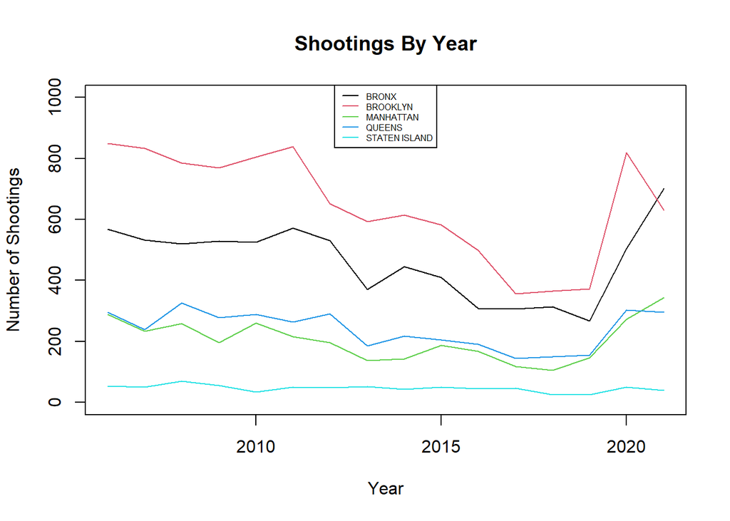

```r
#plotting our piped data

plot(boroData2$YEAR, boroData2$bronx_yt, type="l", col=1, ylim=c(0,1000), xlab="Year", ylab="Number of Shootings", main="Shootings By Year")
lines(boroData2$YEAR, boroData2$brooklyn_yt, type="l", col=2)
lines(boroData2$YEAR, boroData2$manhattan_yt, type="l", col=3)
lines(boroData2$YEAR, boroData2$queens_yt, type="l", col=4)
lines(boroData2$YEAR, boroData2$staten_island_yt, type="l", col=5)
legend("top", legend=c('BRONX', 'BROOKLYN', 'MANHATTAN', 'QUEENS', 'STATEN ISLAND'), col=c(1:5),lwd=1,lty=c(1,1,1,1,1), cex=.5)
```

**Figure 1**

In **Figure 1** we see the number of shootings each year for each borough of New York City. Note, that just because some boroughs have higher numbers it does not mean that shootings are more likely in them. Our NYPD data set did not include population data. Hence, this is frequency and not rate. What does stand out is that there was a decreasing trend up until 2018 and 2019 in nearly all boroughs.

After 2019, there was a dramatic increase in shootings for each borough. Some may assume this is due to a population increase, but the populations in each borough increased prior to 2018 while still maintaining a decrease in shootings. Note that according to census records, every borough increased in population up until 2020. It appears likely that there is some other cause. The pandemic may have indirectly affected these numbers. Impacts on people financially may have led to an increase in crime as a whole.

## Number of Unknown Perpetrators Per Borough by Year

The following data and graph take a look at the number of shootings in each borough over the years where the perpetrator is unknown. There are many categories which could be unknown about a perpetrator. We based the number of unknown perpetrators off the number of unknown age groups. This was chosen because age group had the highest unknown numbers when compared to sex and race. This could be due to age being harder to guess or describe compared to sex and race.

```r
#piping data to focus on date, age group, and borough

age_Data <- nypd_data_fac %>%
    pivot_longer(BOROUGH) %>%
    count(DATE,PERP_AGE_GROUP,value) %>%
    pivot_wider(names_from = value, values_from = n, values_fill = list(n=0))

age_Data
```

```
## # A tibble: 11,719 x 7
##    DATE       PERP_AGE_GROUP BRONX QUEENS MANHATTAN BROOKLYN `STATEN ISLAND`
##    <date>     <fct>          <int>  <int>     <int>    <int>           <int>
##  1 2006-01-01 18-24              1      2         0        0               0
##  2 2006-01-01 25-44              1      1         1        0               0
##  3 2006-01-01 <NA>               0      0         0        2               0
##  4 2006-01-02 18-24              0      0         0        2               1
##  5 2006-01-02 <NA>               0      0         0        1               0
##  6 2006-01-03 18-24              0      0         0        1               0
##  7 2006-01-03 25-44              0      1         0        0               0
##  8 2006-01-03 <NA>               0      1         0        1               0
##  9 2006-01-04 <NA>               1      2         0        1               0
## 10 2006-01-05 18-24              1      0         0        0               0
## # ... with 11,709 more rows
```

```r
#subset of data to focus only on unknown perpetrator according to age group

na_Data <- subset(age_Data, (PERP_AGE_GROUP %in% c(NA)))

na_Data
```

```
## # A tibble: 4,455 x 7
##    DATE       PERP_AGE_GROUP BRONX QUEENS MANHATTAN BROOKLYN `STATEN ISLAND`
##    <date>     <fct>          <int>  <int>     <int>    <int>           <int>
##  1 2006-01-01 <NA>               0      0         0        2               0
##  2 2006-01-02 <NA>               0      0         0        1               0
##  3 2006-01-03 <NA>               0      1         0        1               0
##  4 2006-01-04 <NA>               1      2         0        1               0
##  5 2006-01-05 <NA>               0      0         0        1               0
##  6 2006-01-06 <NA>               1      0         0        0               0
##  7 2006-01-07 <NA>               0      1         0        1               0
##  8 2006-01-08 <NA>               0      1         0        1               1
##  9 2006-01-09 <NA>               2      0         1        0               0
## 10 2006-01-10 <NA>               1      0         0        0               0
## # ... with 4,445 more rows
```

```r
#flooring data to go by year instead of by day

na_Data2 <- na_Data %>%
  group_by(YEAR = floor_date(DATE,"year")) %>%
  summarize(bronx_nat=sum(BRONX), brooklyn_nat=sum(BROOKLYN), manhattan_nat=sum(MANHATTAN), queens_nat=sum(QUEENS), staten_island_nat=sum(`STATEN ISLAND`))

na_Data2
```

```
## # A tibble: 16 x 6
##    YEAR       bronx_nat brooklyn_nat manhattan_nat queens_nat staten_island_nat
##    <date>         <int>        <int>         <int>      <int>             <int>
##  1 2006-01-01       246          412           141        154                10
##  2 2007-01-01       222          407           104        122                11
##  3 2008-01-01       197          348           111        158                12
##  4 2009-01-01       239          399            95        131                17
##  5 2010-01-01       281          474           120        146                11
##  6 2011-01-01       278          488           113        140                 8
##  7 2012-01-01       272          366            87        162                18
##  8 2013-01-01       156          334            56         98                15
##  9 2014-01-01       200          371            55        101                10
## 10 2015-01-01       187          326            74         79                 8
## 11 2016-01-01       129          285            66         75                13
## 12 2017-01-01       130          163            37         54                11
## 13 2018-01-01       117          198            52         45                 2
## 14 2019-01-01       113          177            57         72                10
## 15 2020-01-01       253          514           122        163                18
## 16 2021-01-01       343          389           136        165                16
```

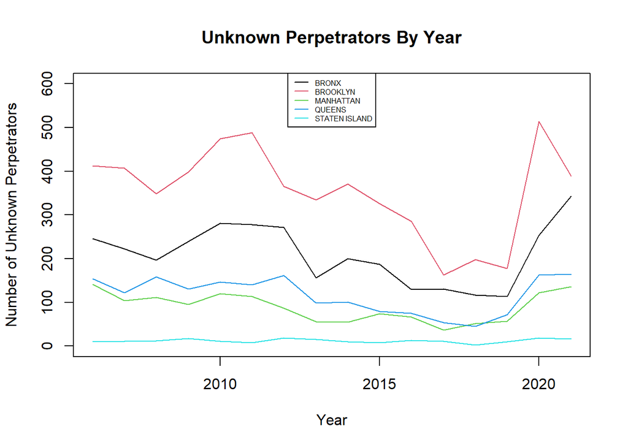

```r
#plotting our piped data

plot(na_Data2$YEAR, na_Data2$bronx_nat, type="l", col=1, ylim=c(0,600), xlab="Year", ylab="Number of Unknown Perpetrators", main="Unknown Perpetrators By Year")
lines(na_Data2$YEAR,na_Data2$brooklyn_nat, type="l", col=2)
lines(na_Data2$YEAR, na_Data2$manhattan_nat, type="l", col=3)
lines(na_Data2$YEAR, na_Data2$queens_nat, type="l", col=4)
lines(na_Data2$YEAR, na_Data2$staten_island_nat, type="l", col=5)
legend("top", legend=c('BRONX', 'BROOKLYN', 'MANHATTAN', 'QUEENS', 'STATEN ISLAND'), col=c(1:5),lwd=1,lty=c(1,1,1,1,1), cex=.5)
```

**Figure 2**

In **Figure 2**, which focuses on unknown perpetrator numbers, we see a very similar trend to **Figure 1**. This is not surprising as it is reasonable that unknown perpetrator numbers increase as shootings increase. We explore this further in Manhattan specifically.

## Focusing on Manhattan Data

For the purpose of this project, we choose to focus on Manhattan or else the project would become extremely long and have too many visuals. Manhattan was chosen because it appears to have an interesting trend. In 2021, Manhattan had more shootings than Queens for the first time in 15 years according to our data. Despite this, Manhattan had less unknown perpetrators than Queens in 2021.

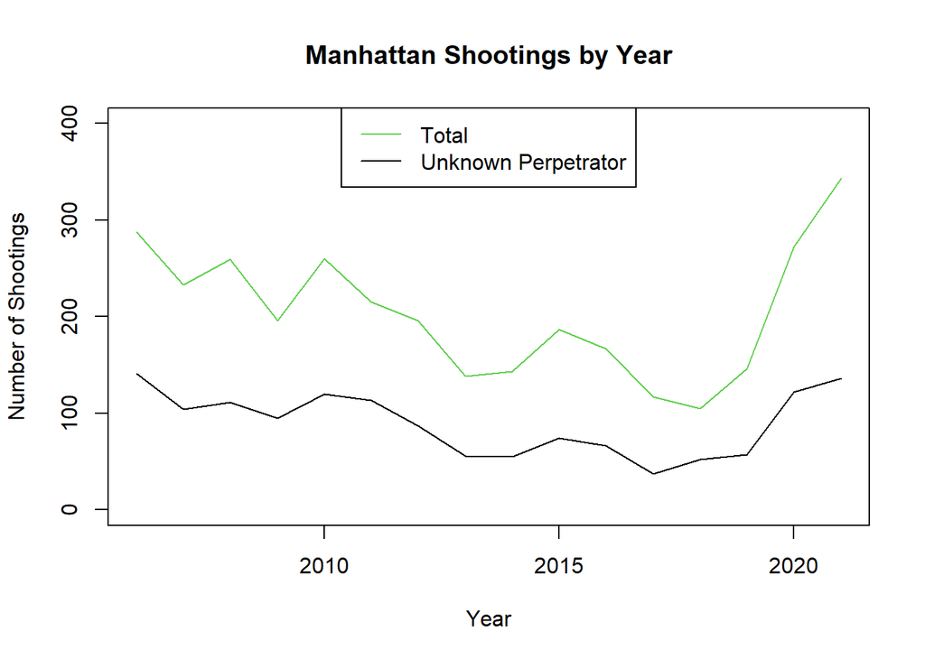

```r
#plotting total numbers and unknown perpetrator numbers in Manhattan

plot(na_Data2$YEAR, na_Data2$manhattan_nat, type="l", col=1, ylim=c(0,400), xlab="Year", ylab="Number of Shootings", main="Manhattan Shootings by Year")
lines(boroData2$YEAR, boroData2$manhattan_yt, type="l", col=3)
legend("top", legend=c('Total', 'Unknown Perpetrator'), col=c(3,1),lwd=1,lty=c(1,1), cex=1)
```

**Figure 3**

## Manhattan Model

Next, we create a smaller data set narrowing down our data on Manhattan. It includes total shootings and unknown perpetrators. We then create a linear model of unknown perpetrators as a function of total shootings. From there we add a prediction column based off our model.

```r
#creating a smaller data set focused on only Manhattan

man_modData <- data.frame(na_Data2$manhattan_nat,boroData2$manhattan_yt)
man_modData
```

```
##    na_Data2.manhattan_nat boroData2.manhattan_yt
## 1                     141                    288
## 2                     104                    233
## 3                     111                    259
## 4                      95                    196
## 5                     120                    260
## 6                     113                    215
## 7                      87                    196
## 8                      56                    138
## 9                      55                    143
## 10                     74                    187
## 11                     66                    167
## 12                     37                    117
## 13                     52                    105
## 14                     57                    146
## 15                    122                    272
## 16                    136                    343
```

```r
#linear model of unknown perpetrator numbers as a function of total number of shootings

man_mod <- lm(man_modData[,1]~man_modData[,2], man_modData)
summary(man_mod)
```

```
##
## Call:
## lm(formula = man_modData[, 1] ~ man_modData[, 2], data = man_modData)
##
## Residuals:
##      Min       1Q   Median       3Q      Max
## -18.1426  -5.6078  -0.5637   5.8319  18.7567
##
## Coefficients:
##                  Estimate Std. Error t value Pr(>|t|)
## (Intercept)      -6.36876    7.98257  -0.798    0.438
## man_modData[, 2]  0.46796    0.03724  12.565 5.17e-09 ***
## ---
## Signif. codes:  0 '***' 0.001 '**' 0.01 '*' 0.05 '.' 0.1 ' ' 1
##
## Residual standard error: 9.764 on 14 degrees of freedom
## Multiple R-squared:  0.9185, Adjusted R-squared:  0.9127
## F-statistic: 157.9 on 1 and 14 DF,  p-value: 5.173e-09
```

```r
#adding a prediction column based off our data
#renaming columns for readability4

man_mod2 <- man_modData %>%
              mutate(Prediction = round(predict(man_mod))) %>%
              rename_with(~c('Unknown', 'Total'), 1:2)

man_mod2
```

```
##    Unknown Total Prediction
## 1      141   288        128
## 2      104   233        103
## 3      111   259        115
## 4       95   196         85
## 5      120   260        115
## 6      113   215         94
## 7       87   196         85
## 8       56   138         58
## 9       55   143         61
## 10      74   187         81
## 11      66   167         72
## 12      37   117         48
## 13      52   105         43
## 14      57   146         62
## 15     122   272        121
## 16     136   343        154
```

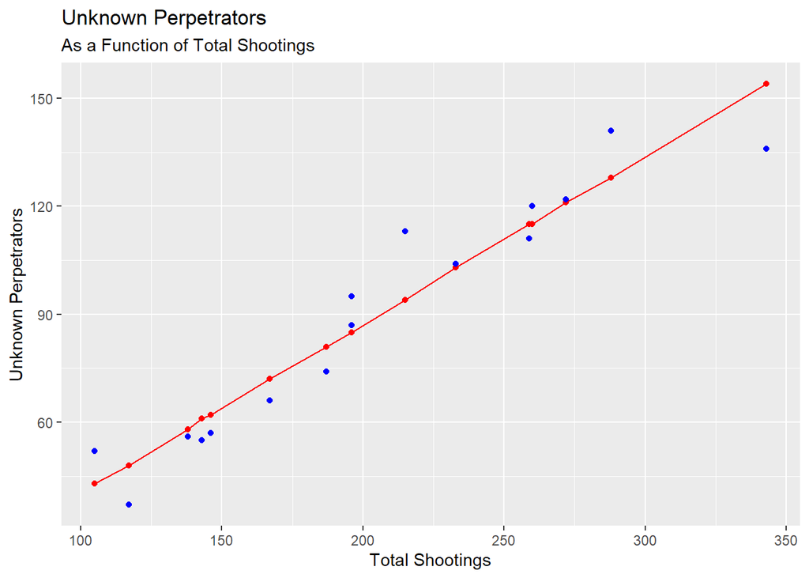

```r
#plot of our prediction model and observed numbers

man_mod2 %>% ggplot()+
  geom_point(aes(x=man_mod2[,2],y=man_mod2[,3]),color = "red")+
  geom_line(aes(x=man_mod2[,2],y=man_mod2[,3]),color = "red")+
  geom_point(aes(x=man_mod2[,2],y=man_mod2[,1]),color = "blue")+
  labs(title="Unknown Perpetrators", subtitle= "As a Function of Total Shootings", x= "Total Shootings", y= "Unknown Perpetrators", color="Legend")+
  scale_color_manual(values=colors)
```

**Figure 4**

**Figure 3** shows the trend of both total shootings and unknown perpetrator shootings in Manhattan. From the data used in this figure, we created a linear model shown in **Figure 4**. Our model’s prediction and our observed data were reasonably close, with slight overestimates and underestimates. Something of note is that the number of unknown perpetrators was lower than our model’s prediction for our highest number of shootings. This means even though shootings went up in 2021, the number of unknown perpetrators was lower than expected.

# Conclusion and References

According to a New York Times article, the NYPD and the Mayor’s office addressed the increase in shootings. They acknowledged the increase in shootings, but also mentioned a decrease in murders. They credited this to a dramatic increase in arrests. While we did not analyze murder numbers, our data from **Figure 4** supports this. Fewer unknown perpetrators means that the police have been arresting more perpetrators.

The following news article was used in our analysis:

“Shootings Rise in New York, Coloring Perceptions of City’s Safety”  
New York Times Article: https://www.nytimes.com/2022/04/06/nyregion/shootings-new-york-city-safety.html

# Bias

In this section we mention possible sources of bias.

First, with the current controversies involving the police in the news, one may view the police negatively or positively. I tried to remain neutral and let the data speak for itself. Second, choosing to compare boroughs rather than precincts was out of convenience. Precinct comparison may have provided more insight on what made a difference over the years. This would require a small subset of the data since there are a large amount of precincts. Third, choosing Manhattan because of the trends we found may have led us to less impactful conclusions than the other boroughs.